# Actividad 1.11A Time Series

Rey Iván De La Fuente Chávez

2026-09-07

## 1. Sales data

Se tienen ventas trimestrales de televisores durante cuatro años, expresadas en miles.

```r
ventas <- c(4.8, 4.1, 6.0, 6.5,
            5.8, 5.2, 6.8, 7.4,
            6.0, 5.6, 7.5, 7.8,
            6.3, 5.9, 8.0, 8.4)

tiempo <- 1:16
ventas_ts <- ts(ventas, start = c(1, 1), frequency = 4)

ventas_ts
```

```
##   Qtr1 Qtr2 Qtr3 Qtr4
## 1  4.8  4.1  6.0  6.5
## 2  5.8  5.2  6.8  7.4
## 3  6.0  5.6  7.5  7.8
## 4  6.3  5.9  8.0  8.4
```

## 2. Trend and seasonality

### Time series

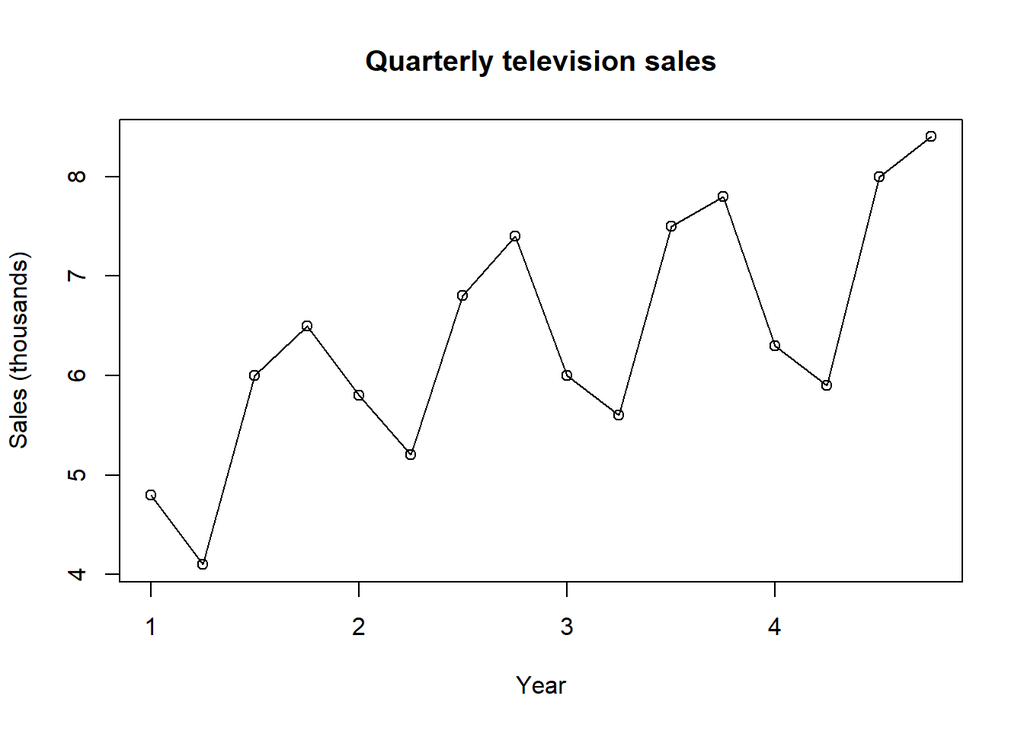

```r
plot(ventas_ts,
     type = "o",
     xlab = "Year",
     ylab = "Sales (thousands)",
     main = "Quarterly television sales")
```

La serie no es stationary, ya que presenta una trend general creciente y un seasonal pattern trimestral repetitivo. En particular, el segundo trimestre suele presentar las ventas más bajas y el cuarto las más altas.

### Autocorrelation (ACF)

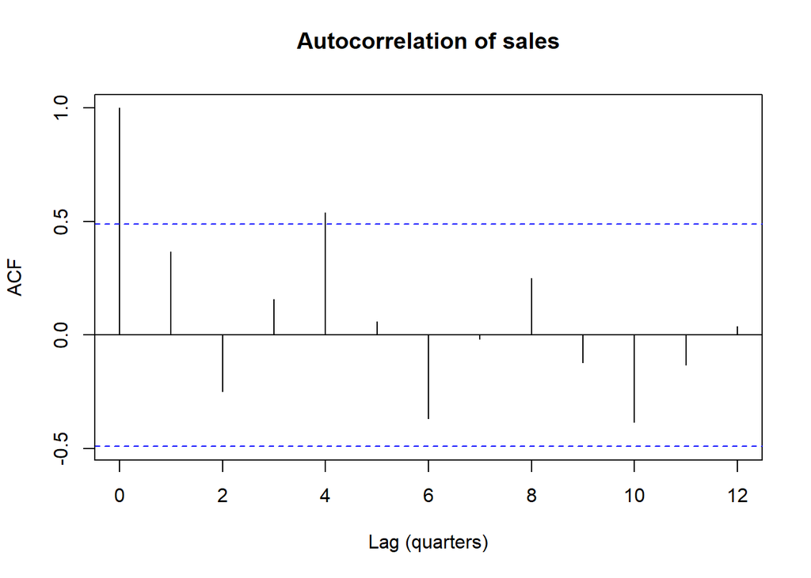

```r
acf(as.numeric(ventas_ts),
    lag.max = 12,
    xlab = "Lag (quarters)",
    main = "Autocorrelation of sales")
```

La ACF muestra un valor importante en lag 4, consistente con quarterly seasonality: observaciones del mismo trimestre en años consecutivos tienden a comportarse de manera semejante.

### Additive and multiplicative models

Se prueban las dos formas de decomposition para comparar cuál representa mejor la serie.

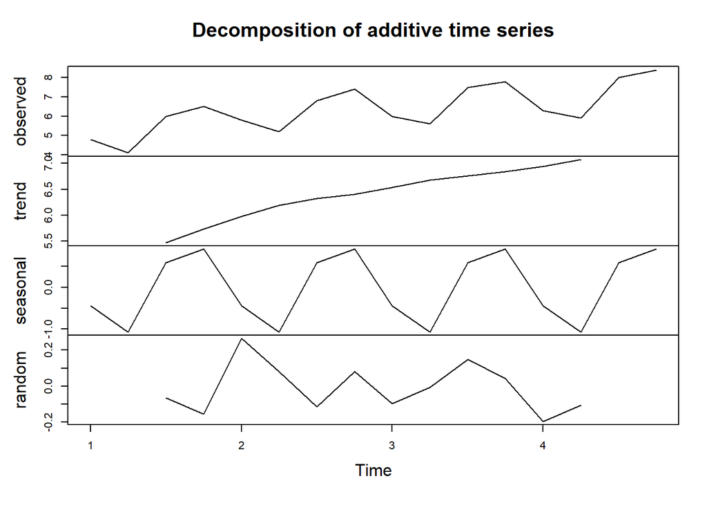

```r
descomp_add <- decompose(ventas_ts, type = "additive")
descomp_mult <- decompose(ventas_ts, type = "multiplicative")

plot(descomp_add)
```

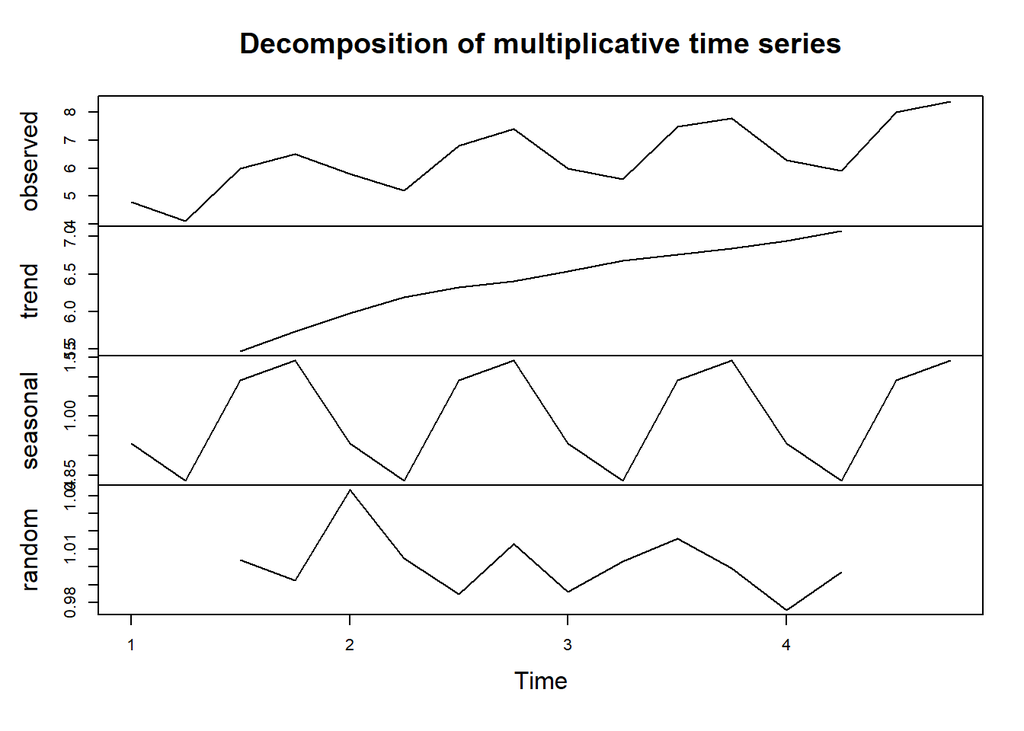

```r
plot(descomp_mult)
```

Ambas decompositions representan el seasonal pattern. La elección final entre una estructura additive o multiplicative se realiza comparando los forecast errors de los modelos ajustados.

## 3. Seasonal indices and deseasonalized series

```r
indice_add <- tapply(descomp_add$seasonal,
                     cycle(ventas_ts),
                     mean,
                     na.rm = TRUE)

indice_mult <- tapply(descomp_mult$seasonal,
                      cycle(ventas_ts),
                      mean,
                      na.rm = TRUE)

indices <- data.frame(
  Quarter = 1:4,
  Additive = as.numeric(indice_add),
  Multiplicative = as.numeric(indice_mult)
)

round(indices, 4)
```

```
##   Quarter Additive Multiplicative
## 1       1  -0.4396         0.9307
## 2       2  -1.0688         0.8364
## 3       3   0.5896         1.0915
## 4       4   0.9187         1.1414
```

Los seasonal indices confirman el patrón observado. En el multiplicative model, Quarter 1 se encuentra aproximadamente 6.9% por debajo de la trend y Quarter 2 cerca de 16.4% por debajo. En cambio, Quarter 3 y Quarter 4 se encuentran aproximadamente 9.2% y 14.1% por encima, respectivamente.

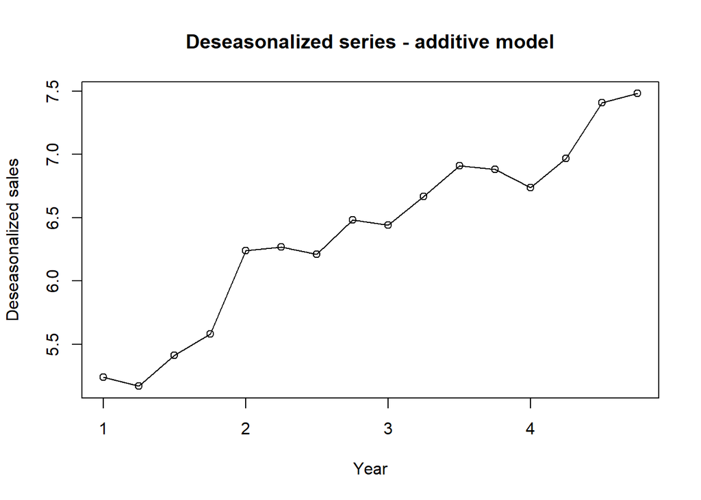

```r
estacional_add <- indice_add[cycle(ventas_ts)]
estacional_mult <- indice_mult[cycle(ventas_ts)]

ventas_des_add <- ventas_ts - estacional_add
ventas_des_mult <- ventas_ts / estacional_mult

plot(ventas_des_add,
     type = "o",
     xlab = "Year",
     ylab = "Deseasonalized sales",
     main = "Deseasonalized series - additive model")
```

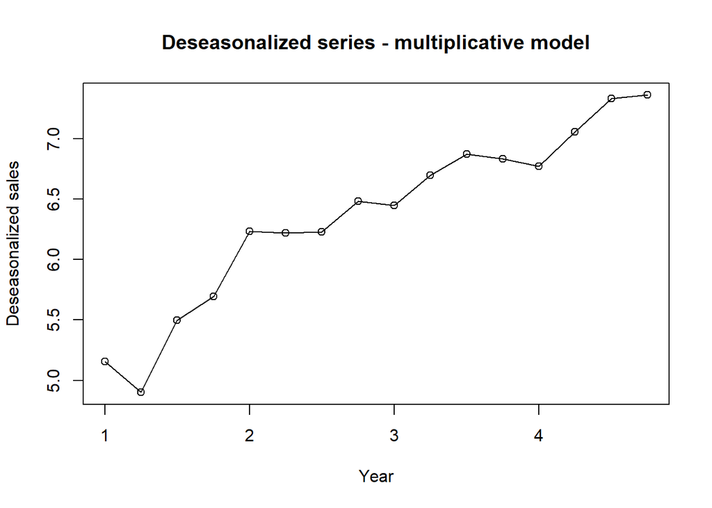

```r
plot(ventas_des_mult,
     type = "o",
     xlab = "Year",
     ylab = "Deseasonalized sales",
     main = "Deseasonalized series - multiplicative model")
```

Al eliminar el seasonal effect, en ambas deseasonalized series se observa con mayor claridad la creciente trend de las ventas.

## 4. Linear trend model

Se ajustan linear models sobre las deseasonalized sales. El multiplicative model se analiza con mayor detalle y después se compara con los demás mediante sus forecast errors.

```r
modelo_lineal_add <- lm(as.numeric(ventas_des_add) ~ tiempo)
modelo_lineal_mult <- lm(as.numeric(ventas_des_mult) ~ tiempo)

summary(modelo_lineal_mult)
```

```
##
## Call:
## lm(formula = as.numeric(ventas_des_mult) ~ tiempo)
##
## Residuals:
##     Min      1Q  Median      3Q     Max
## -0.5007 -0.1001  0.0037  0.1207  0.3872
##
## Coefficients:
##             Estimate Std. Error t value Pr(>|t|)
## (Intercept)  5.10804    0.11171   45.73  < 2e-16 ***
## tiempo       0.14738    0.01155   12.76 4.25e-09 ***
## ---
## Signif. codes:  0 '***' 0.001 '**' 0.01 '*' 0.05 '.' 0.1 ' ' 1
##
## Residual standard error: 0.213 on 14 degrees of freedom
## Multiple R-squared:  0.9208, Adjusted R-squared:  0.9151
## F-statistic: 162.7 on 1 and 14 DF,  p-value: 4.248e-09
```

Para el multiplicative model, la estimated trend es aproximadamente:

$$\hat{y}=5.1080+0.1474t$$

El coefficient de time es significant ($p=4.25\times10^{-9}$), por lo que existe evidencia de una increasing trend. El model también es globally significant ($p=4.25\times10^{-9}$) y explica aproximadamente 92.1% de la variability de las deseasonalized sales ($R^2=0.9208$).

### Residual analysis

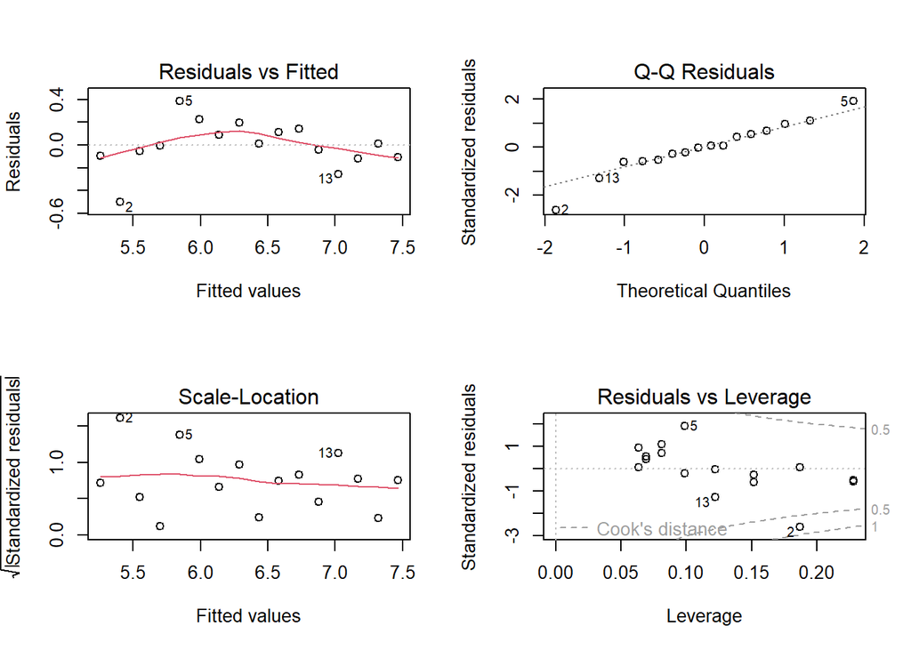

```r
par(mfrow = c(2, 2))
plot(modelo_lineal_mult)
```

```r
par(mfrow = c(1, 1))

shapiro.test(residuals(modelo_lineal_mult))
```

```
##
##  Shapiro-Wilk normality test
##
## data:  residuals(modelo_lineal_mult)
## W = 0.96379, p-value = 0.7307
```

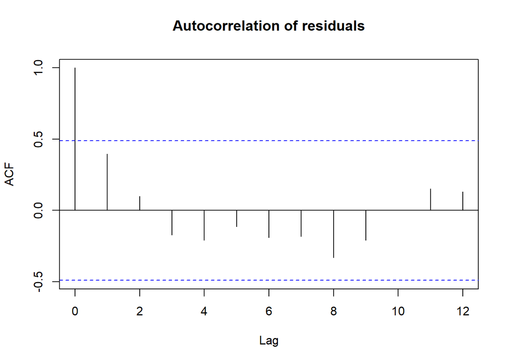

```r
acf(residuals(modelo_lineal_mult),
    main = "Autocorrelation of residuals")
```

Los residuals no muestran un patrón fuerte de curvature o un cambio claro de variability. La observation 2 destaca respecto a las demás y conviene tenerla presente como una potentially influential observation. La Shapiro-Wilk test obtiene $p=0.7307$, por lo que no se rechaza normality. Además, la residual ACF no presenta lags claramente significant, por lo que no se observa evidencia fuerte de remaining temporal dependence.

## 5. Quadratic model

Se agrega el quadratic term del tiempo para explorar una nonlinear trend.

```r
tiempo2 <- tiempo^2

modelo_cuad_mult <- lm(as.numeric(ventas_des_mult) ~ tiempo + tiempo2)
summary(modelo_cuad_mult)
```

```
##
## Call:
## lm(formula = as.numeric(ventas_des_mult) ~ tiempo + tiempo2)
##
## Residuals:
##      Min       1Q   Median       3Q      Max
## -0.36986 -0.07058 -0.00100  0.11345  0.33110
##
## Coefficients:
##              Estimate Std. Error t value Pr(>|t|)
## (Intercept)  4.790283   0.152429  31.426 1.20e-13 ***
## tiempo       0.253302   0.041269   6.138 3.56e-05 ***
## tiempo2     -0.006231   0.002360  -2.640   0.0204 *
## ---
## Signif. codes:  0 '***' 0.001 '**' 0.01 '*' 0.05 '.' 0.1 ' ' 1
##
## Residual standard error: 0.1784 on 13 degrees of freedom
## Multiple R-squared:  0.9484, Adjusted R-squared:  0.9405
## F-statistic: 119.6 on 2 and 13 DF,  p-value: 4.268e-09
```

El estimated quadratic model es aproximadamente:

$$\hat{y}=4.7903+0.2533t-0.00623t^2$$

Tanto el linear term ($p=3.56\times10^{-5}$) como el quadratic term ($p=0.0204$) son significant. El model es globally significant y alcanza un $R^2=0.9484$. El negative coefficient de $t^2$ indica que las ventas siguen aumentando, pero el growth rate se va reduciendo con el tiempo.

## 6. MSE and MAPE

Se comparan tres models: additive linear, multiplicative linear y multiplicative quadratic.

```r
pred_add_lin <- fitted(modelo_lineal_add) + estacional_add
pred_mult_lin <- fitted(modelo_lineal_mult) * estacional_mult
pred_mult_cuad <- fitted(modelo_cuad_mult) * estacional_mult

metricas <- function(real, pred) {
  c(
    MSE = mean((real - pred)^2, na.rm = TRUE),
    MAPE = mean(abs((real - pred) / real), na.rm = TRUE) * 100
  )
}

comparacion <- rbind(
  "Additive linear" = metricas(ventas, pred_add_lin),
  "Multiplicative linear" = metricas(ventas, pred_mult_lin),
  "Multiplicative quadratic" = metricas(ventas, pred_mult_cuad)
)

round(comparacion, 4)
```

```
##                             MSE   MAPE
## Additive linear          0.0329 2.4921
## Multiplicative linear    0.0330 2.4395
## Multiplicative quadratic 0.0219 1.9493
```

El multiplicative quadratic model presenta los menores forecast errors, con un Mean Squared Error (MSE) de 0.0219 y un Mean Absolute Percentage Error (MAPE) de 1.9493%. Por lo tanto, es el mejor de los tres models evaluados. Los dos linear models presentan resultados muy similares entre sí, pero ambos tienen mayores errors.

```r
mejor_MSE <- rownames(comparacion)[which.min(comparacion[, "MSE"])]
mejor_MAPE <- rownames(comparacion)[which.min(comparacion[, "MAPE"])]

cat("Lowest MSE:", mejor_MSE, "\n")
```

```
## Lowest MSE: Multiplicative quadratic
```

```r
cat("Lowest MAPE:", mejor_MAPE, "\n")
```

```
## Lowest MAPE: Multiplicative quadratic
```

## 7. Forecast for the next year

Se calculan los forecasts de los cuatro quarters del Year 5 para los tres models analizados.

```r
futuro <- data.frame(
  tiempo = 17:20,
  tiempo2 = (17:20)^2
)

est_add_fut <- as.numeric(indice_add[1:4])
est_mult_fut <- as.numeric(indice_mult[1:4])

pron_add_lin <- predict(modelo_lineal_add, newdata = futuro) + est_add_fut
pron_mult_lin <- predict(modelo_lineal_mult, newdata = futuro) * est_mult_fut
pron_mult_cuad <- predict(modelo_cuad_mult, newdata = futuro) * est_mult_fut

pronosticos <- data.frame(
  Year = rep(5, 4),
  Quarter = 1:4,
  Additive_linear = pron_add_lin,
  Multiplicative_linear = pron_mult_lin,
  Multiplicative_quadratic = pron_mult_cuad
)

round(pronosticos, 3)
```

```
##   Year Quarter Additive_linear Multiplicative_linear Multiplicative_quadratic
## 1    5       1           7.184                 7.086                    6.790
## 2    5       2           6.701                 6.491                    6.131
## 3    5       3           8.505                 8.632                    8.027
## 4    5       4           8.980                 9.195                    8.406
```

Con el selected model, los forecasts para Year 5 son 6.790, 6.131, 8.027 y 8.406 miles de televisores para Quarter 1 a Quarter 4, respectivamente. Se conserva el seasonal pattern, con menores ventas en Quarter 2 y mayores ventas en Quarter 4.

### Final plot

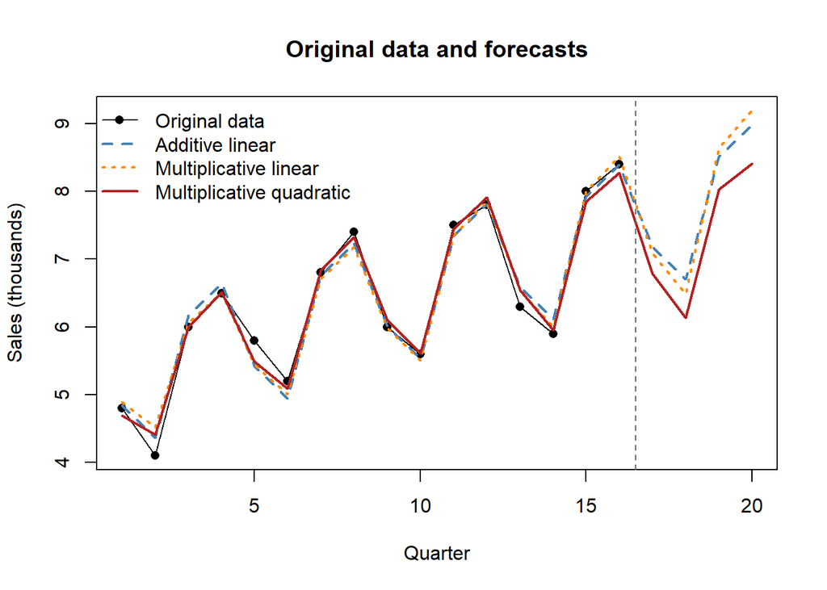

```r
tiempo_total <- 1:20
ventas_total <- c(ventas, rep(NA, 4))

serie_add_lin <- c(pred_add_lin, pron_add_lin)
serie_mult_lin <- c(pred_mult_lin, pron_mult_lin)
serie_mult_cuad <- c(pred_mult_cuad, pron_mult_cuad)

plot(tiempo_total, ventas_total,
     type = "o",
     pch = 16,
     col = "black",
     xlab = "Quarter",
     ylab = "Sales (thousands)",
     main = "Original data and forecasts",
     ylim = range(c(ventas, serie_add_lin,
                    serie_mult_lin, serie_mult_cuad)))

lines(tiempo_total, serie_add_lin,
      lty = 2, col = "steelblue", lwd = 2)
lines(tiempo_total, serie_mult_lin,
      lty = 3, col = "darkorange", lwd = 2)
lines(tiempo_total, serie_mult_cuad,
      lty = 1, col = "firebrick", lwd = 2)
abline(v = 16.5, lty = 2, col = "gray40")

legend("topleft",
       legend = c("Original data",
                  "Additive linear",
                  "Multiplicative linear",
                  "Multiplicative quadratic"),
       col = c("black", "steelblue", "darkorange", "firebrick"),
       lty = c(1, 2, 3, 1),
       lwd = c(1, 2, 2, 2),
       pch = c(16, NA, NA, NA),
       bty = "n")
```

La gráfica permite comparar los historical fits y los forecasts. Los tres models reproducen el quarterly seasonal pattern, pero el multiplicative quadratic model se ajusta mejor de acuerdo con MSE y MAPE y proyecta una desaceleración del growth para Year 5.

## Conclusion

La sales time series no es stationary porque presenta una increasing trend y quarterly seasonality. Después de obtener las deseasonalized series se ajustaron tres models. El multiplicative quadratic model fue el mejor, con MSE = 0.0219 y MAPE = 1.9493%, y sus terms resultaron statistically significant. Por ello se utiliza para forecast Year 5, manteniendo el seasonal pattern de menores ventas en Quarter 2 y mayores ventas en Quarter 4.

## Declaratoria de uso de IA

**Opción B. Se utilizó IA.**

Herramienta: ChatGPT.

Uso realizado: apoyo para estructurar el procedure, escribir y revisar el R code y organizar el time series analysis.

Secciones donde se utilizó: desarrollo del code, model comparison y redacción de interpretations.

Validación realizada por el estudiante: el code fue ejecutado y rendered en RStudio; los outputs obtenidos se utilizaron para completar las interpretations.

Responsabilidad: el estudiante revisará, verificará y asumirá la responsabilidad del contenido final entregado.